# Predictive Sensory Modelling

Joshua Lomax

2024-04-16

### Packages

```r
required_packages <- c("tidyverse", "readxl", "reshape2", "openxlsx", "readr", "AMR", # data processing
                       "ggplot2", "ggrepel", "corrplot", "gridExtra", "GGally", # Plotting
                       "factoextra", "FactoMineR", "survminer", "agricolae", # Multivariate Analysis
                        "caret", "randomForest", "MultivariateRandomForest", #linear models
                       "gbm", "BGLR"
                       )
pacman::p_load(char = basename(required_packages), install = F)

devtools::source_gist("7f63547158ecdbacf31b54a58af0d1cc", filename = "util.R") # Ido's gist
```

### data preprocessing

The first step is to create a data matrix with all of our sensory and metabolite data. The matrix can then be normalised and na’s can be imputed.

```r
# Extract SD1_Original_Data sheet from SD1_dataset_tomato.xlsx file
tom_og <- read_excel("data/supplemental_datasets/SD1_dataset_tomato.xlsx", sheet = "SD1_Original_Data")

# Remove columns not needed for most computation
tom_og <- tom_og %>% select(-species, -`panel number`)

# For the following metabolites, not every sample in the population has been quantified (e.g. missing data)
mets_with_missing_data <- c("firmness",
                            "citric",
                            "fructose",
                            "glucose",
                            "sucrose",
                            "Limonene",
                            "Nerylacetone")

# Thus, we will impute any missing data with the mean of the non-missing samples in the population

# Calculate means of non-missing samples for each metabolite containing missing data
means <- tom_og %>%
  select(mets_with_missing_data) %>%
  colMeans(na.rm = T)

# For each metabolite with missing data we find which samples are NAs
#   and replace the NAs with the mean of the non-NA samples

for(i in 1:length(mets_with_missing_data)){
  tom_og[is.na(bb_og[, mets_with_missing_data[i]]), mets_with_missing_data[i]] <- means[i]
}

# Scale all features and responses to N(0,1)
tom_og[,2:length(tom_og)]  <- scale(tom_og[,2:length(tom_og)])

# Write new scaled/imputed data to .csv file for clean input to other scripts
write.csv(tom_og, "./data/input/tom_imputed_scaled.csv", row.names = F)
```

### Sensory characterisation data visualisation

In the case that we have trained panel data, a great way to visualise the data is to use a PCA.

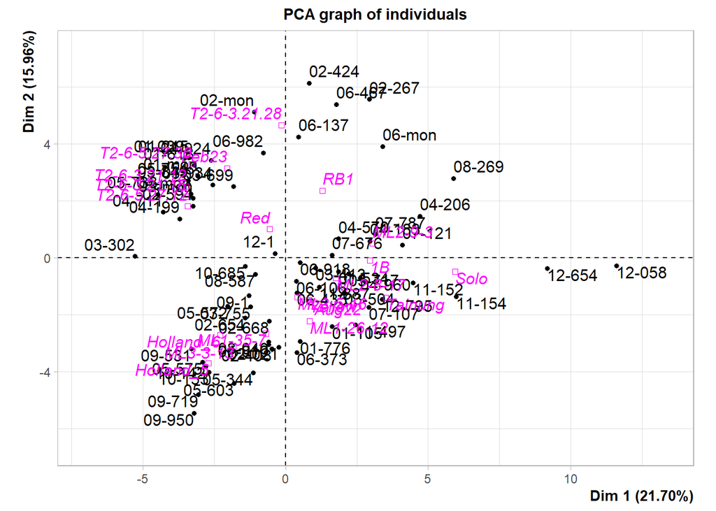

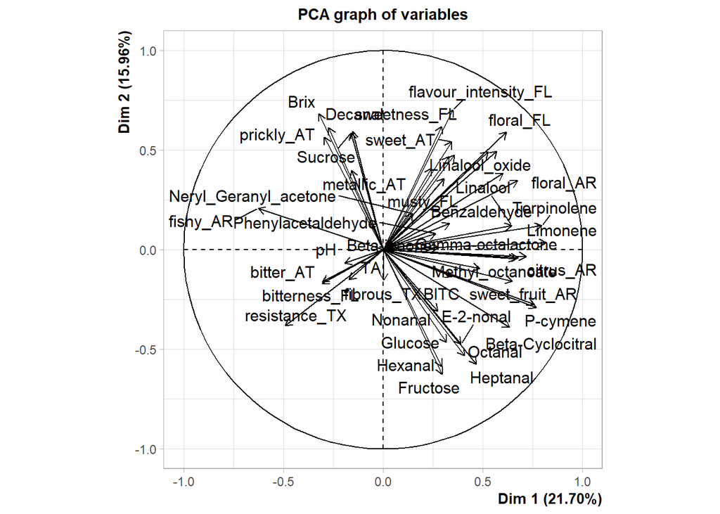

```r
genotype_table <- read_excel("data/papaya_sample_meta_data.xlsx",
                             sheet = "meta_data")

complete_matrix <- read_excel("data/complete_data_matrix.xlsx",
                              sheet = "Sheet1")

initial_pca_data <- complete_matrix %>%
                    column_to_rownames("ID")

# choose the number of components using your favourite method (e.g. elbow or straight line visual method)
initial_pca <- PCA(initial_pca_data,
                   scale.unit = TRUE,
                   graph = T,
                   quali.sup = 1:3)
```

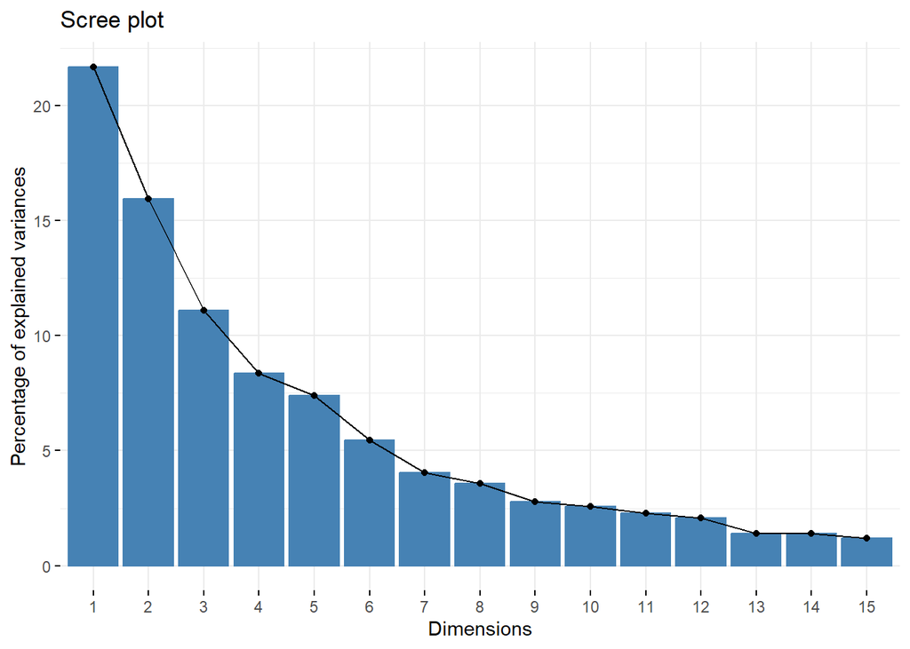

```r
# or Visualize the eigenvalues/variances of the dimensions
fviz_screeplot(initial_pca, ncp=15)
```

```r
# choose the number of components using your favourite method (e.g. elbow or straight line visual method)
```

Using the straight line visual method we will choose ncp = 7

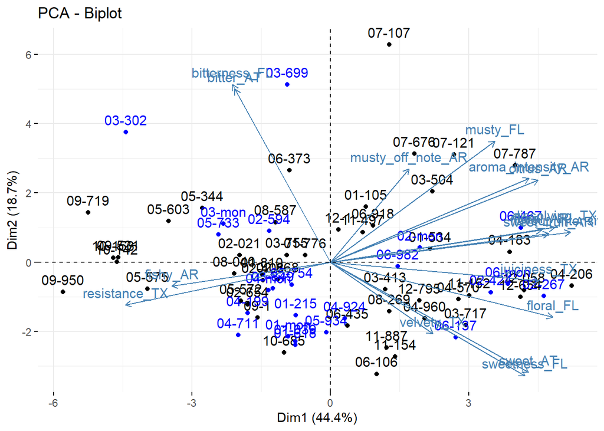

```r
# adjust preliminary PCA with updated data

sensory_meta <- data.frame("var" = c("aroma_intensity_AR","sweet_fruit_AR","musty_off_note_AR",
                                     "fishy_AR","citrus_AR","floral_AR", "resistance_TX",
                                     "velvety_TX","juiciness_TX","dissolving_TX","fibrous_TX",
                                     "flavour_intensity_FL","sweetness_FL","bitterness_FL",
                                     "musty_FL","floral_FL", "bitter_AT","sweet_AT",
                                     "metallic_AT","prickly_AT"),

                           "group" = c("aroma","aroma","aroma","aroma","aroma","aroma",
                                       "texture","texture","texture","texture","texture",
                                       "flavour","flavour","flavour","flavour","flavour",
                                       "aftertaste","aftertaste","aftertaste","aftertaste"))

# You may need to remove some variables due to preliminary data analysis

# e.g., panelists failed to score samples consistently using a descriptor or there were technical issues measuring metabolites

No_aroma <- c("P-cymene", "Beta-Cyclocitral","Terpinene","Methyl_octanoate")

cutvariables <- c("prickly_AT", "fibrous_TX", "metallic_AT", No_aroma)

PCA_data <- complete_matrix %>%
            column_to_rownames("ID") %>%
            select(-(all_of(cutvariables)))

# store a PCA using the appropriate variables and number of dimensions
PCA_vocs <- PCA(PCA_data,
                scale.unit = TRUE,
                ncp = 7,
                graph = FALSE,
                quali.sup = 1:27, # omit columns from PCA; e.g. metadata
                ind.sup = 47:69) #  omit rows from PCA; remove unnecessary samples

# A biplot can be used to visualise this data

# The factoextra package has a default command to create a biplot
# but it can be difficult to customise for aesthetics
fviz_pca_biplot(PCA_vocs)
```

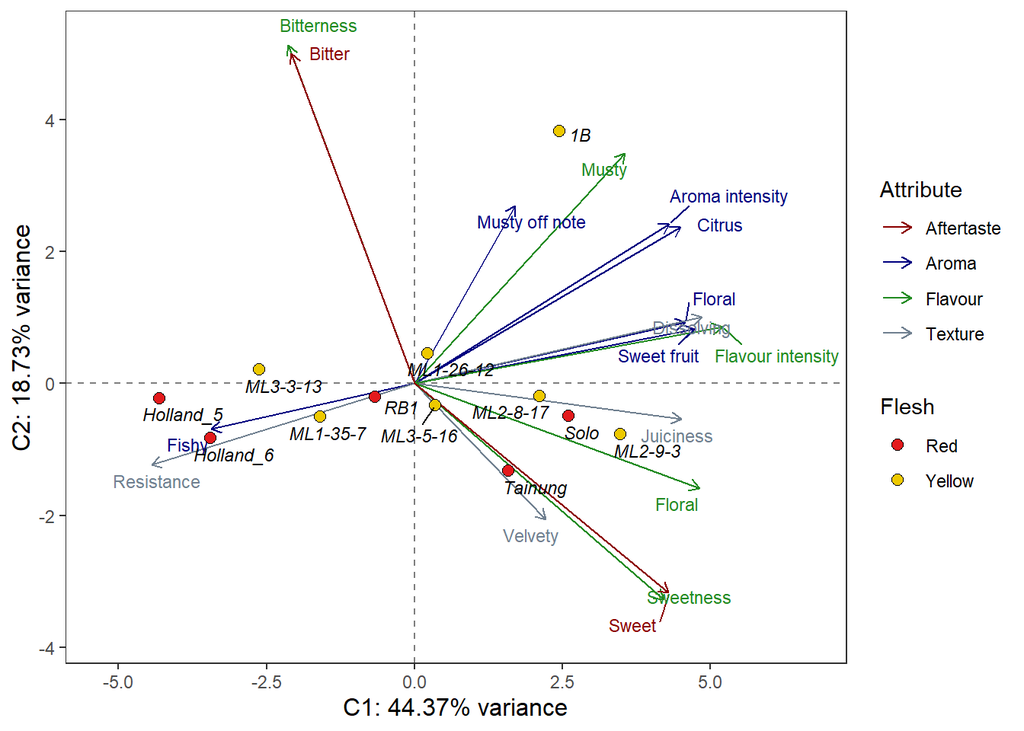

```r
# make a data frame of top variables based on visual assessment

topvars <- PCA_vocs$var$contrib [,1:2] %>% # use the first two dimensions of the PCA
           as.data.frame() %>%
           rownames_to_column(var = "species") %>% #move variable names to a column: "species"
           mutate (contribution = Dim.1 + Dim.2) %>% # create a column with combined contribution metric                                                           for each variable
           top_n(20, contribution) # filter list of variables to include the 20 most discerning variables                                       in the PCA

# make a dataframe with variable coordinates for arrows
PCAvar_coords <- PCA_vocs$var$coord[topvars$species,1:2] %>% #coordinates for top variables
                 as.data.frame() %>%
                 rownames_to_column(var = "var") %>%
                 left_join(sensory_meta) %>%
                 mutate(Category = snakecase::to_title_case(group),
                 sensory_label = snakecase::to_sentence_case(sub("_[A-Z]+$", "", var)))

# create a scale value to the size of the scatter plot to adjust variable coordinates
var <- facto_summarize(PCA_vocs,
                       element = "var",
                       result = c("coord", "contrib", "cos2"))

colnames(var)[2:3] <- c("x", "y")

ind <- data.frame(PCA_vocs$ind$coord[, drop = FALSE], stringsAsFactors = TRUE)
colnames(ind) <- c("x", "y")

r <- min((max(ind[, "x"]) - min(ind[, "x"])/(max(var[, "x"]) - min(var[, "x"]))),
         (max(ind[, "y"]) - min(ind[, "y"])/(max(var[,"y"]) - min(var[, "y"]))))

# update the variable coordinates
PCAvar_plot_data <- PCAvar_coords %>%
                    as_tibble() %>%
                    mutate(across(starts_with("Dim"), ~r*0.7*.x))

# get coordinates for individuals to map group means with meta data for aesthetics
PCAvoctable <- PCA_vocs$ind$coord %>%
               as.data.frame() %>%
               rownames_to_column("ID") %>%
               left_join(genotype_table)

#create a table with the average coordinates for each phenotype
Mean_coords <- PCAvoctable %>%
               group_by(Genotype,Flesh) %>%
               summarise(across(where(is.numeric), ~mean(.x, na.rm = TRUE)))

# choose colours
my_colours <- c("#E31A1C","gold2")

# Get component variance information for axis labels
percentVar <- PCA_vocs$eig[1:2,2]

#plot PCA coords using ggplot

ggplot(Mean_coords) + # create a plot using our data points
  aes(x = Dim.1, y = Dim.2, fill = Flesh) + # assign data to axis and meta data to fill

  geom_hline(yintercept = 0, # add horizontal line along x-axis; dimension 1
             alpha = 0.5,
             linetype = "dashed",
             linewidth = 0.5) +
  geom_vline(xintercept = 0, # add vertical line along y-axis; dimension 2
             alpha = 0.5,
             linetype = "dashed",
             linewidth = 0.5) +

  geom_segment(mapping = aes(colour = Category, #add arrows for variables
                             xend = Dim.1,
                             yend = Dim.2),
               data = PCAvar_plot_data,
               inherit.aes = F,
               x = 0, y = 0, linewidth = 0.4,
               arrow = arrow(angle = 30, length = unit(0.2, "cm"))) +

  geom_text_repel(mapping = aes(colour = Category, #add text to variable arrows
                                x = Dim.1,
                                y = Dim.2,
                                label = sensory_label),
                  data = PCAvar_plot_data,
                  inherit.aes = F,
                  hjust = -0.09, vjust = -0.6, size = 3) +

  scale_color_manual(values = c("#8B0000", "#000080", "#228B22", "#708090")) + #colours for variable arrows

  geom_point(shape = 21, alpha = 1, size=2.5) + # modify data points
  scale_fill_manual(values = my_colours) +

  geom_text_repel(label = Mean_coords$Genotype, # add text to data points
                  size=3, hjust=0.7, vjust=-0.2,
                  colour = "black", fontface = "italic") +
  xlim(-5.3, 6.7) + ylim(-3.8,5.2) + # adjust x- and y-axis to fit arrows and text

  theme_bw() + # remove background, add border, remove grid lines and change title size
  theme(panel.grid.major = element_blank(),
        panel.grid.minor = element_blank(),
        axis.title = element_text(size=12)) +

  guides(colour=guide_legend(override.aes = list(label="")), # modify legend symbols
         text="none") +

  labs( x=glue::glue("C1: {round(percentVar[1],2)}% variance"), # modify axis and legend titles
        y=glue::glue("C2: {round(percentVar[2],2)}% variance"), fill="Flesh",
        colour="Attribute")
```

This code can be used as a template to also plot consumer data. Such as the papaya consumption habits of the participants compared with each groups over-all liking of the papaya samples.

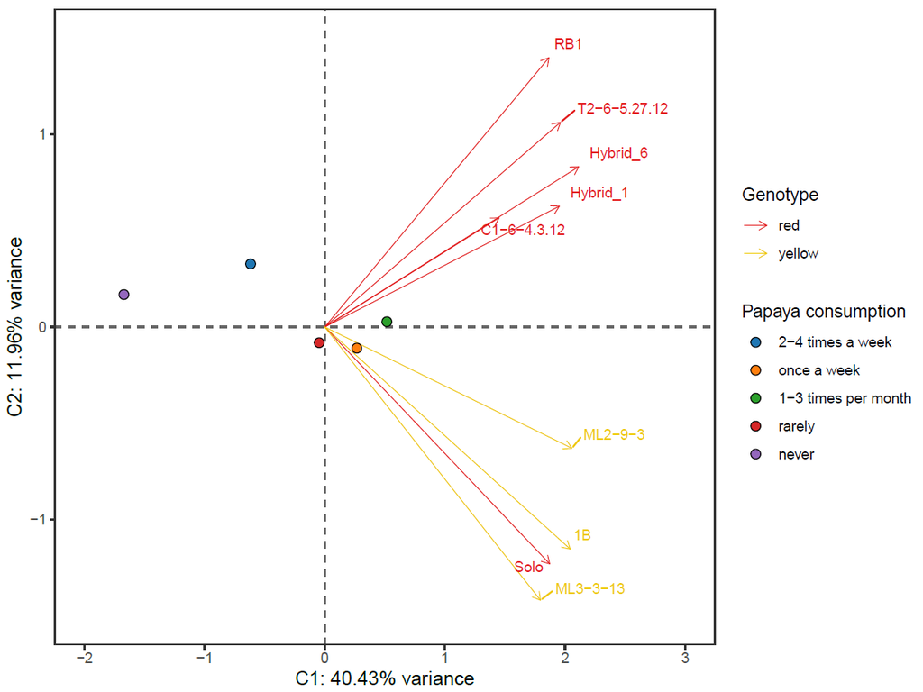

### Consumer survey data visualisation

```r
liking_data <- read_xlsx("data/consumer_data/consumer_data.xlsx",
                         sheet = "all_data") %>%
                mutate(age = as.numeric(age)) %>%
                mutate(age_brackets = age_groups(age, split_at = "tens"),
                       consumption = as.character(consumption))

key <- read_xlsx("data/consumer_data/consumer_data.xlsx", sheet = "key")

factorial_model <- aov(liking ~ sample*age*consumption, data = liking_data)
summary(factorial_model)
```

```
##                          Df Sum Sq Mean Sq F value   Pr(>F)
## sample                    8 113394   14174  41.568  < 2e-16 ***
## age                       1      9       9   0.025   0.8736
## consumption               4  16697    4174  12.242 9.95e-10 ***
## sample:age                8   1692     211   0.620   0.7614
## sample:consumption       32   6662     208   0.611   0.9573
## age:consumption           4   3201     800   2.347   0.0528 .
## sample:age:consumption   32   6739     211   0.618   0.9537
## Residuals              1035 352921     341
## ---
## Signif. codes:  0 '***' 0.001 '**' 0.01 '*' 0.05 '.' 0.1 ' ' 1
```

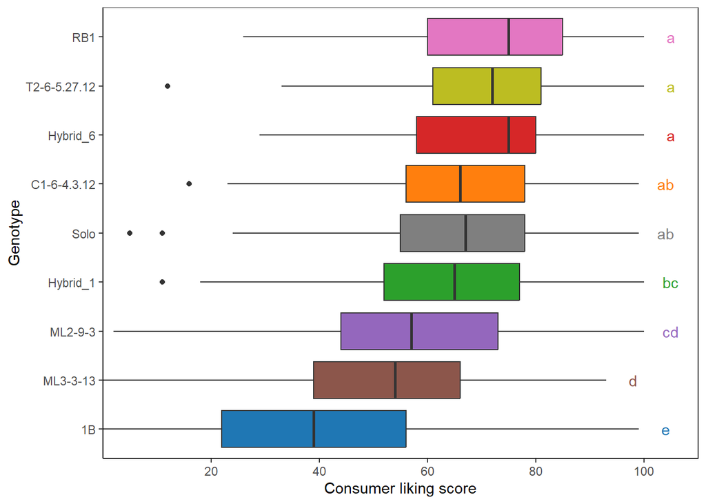

```r
tHSD <- HSD.test(factorial_model, "sample")
con_tHSD <- HSD.test(factorial_model, "consumption")
nine_colours <- c("#1f77b4", "#ff7f0e", "#2ca02c", "#d62728", "#9467bd",
                  "#8c564b", "#e377c2", "#7f7f7f", "#bcbd22")
#   boxplot

ranges <- data.frame(tHSD$means) %>% rownames_to_column(var = "sample")
groups <- data.frame(tHSD$groups) %>% rownames_to_column(var = "sample") %>% select(-liking)
label_df <- left_join(ranges, groups, join_by(sample)) %>% mutate(y = Max + 5)

#Generate ggplot

ggplot(liking_data, aes(x = reorder(sample,+liking), y = liking)) +
  geom_boxplot(aes(fill = sample)) +
  geom_text(data = label_df, aes(x = sample, y = y,
                                 label = groups, color = sample)) +
  scale_color_manual(values = nine_colours) +
  scale_fill_manual(values = nine_colours) +
  scale_y_continuous(expand = c(0,0), limits = c(0,110),
                     breaks = c(20,40,60,80,100)) +
  coord_flip() +
  theme_bw()+
  theme(legend.position = "none", panel.grid.major = element_blank(),
        panel.grid.minor = element_blank(), panel.background = element_blank(),
        axis.line = element_line(colour = "black")) +
  labs(y="Consumer liking score", x="Genotype")
```

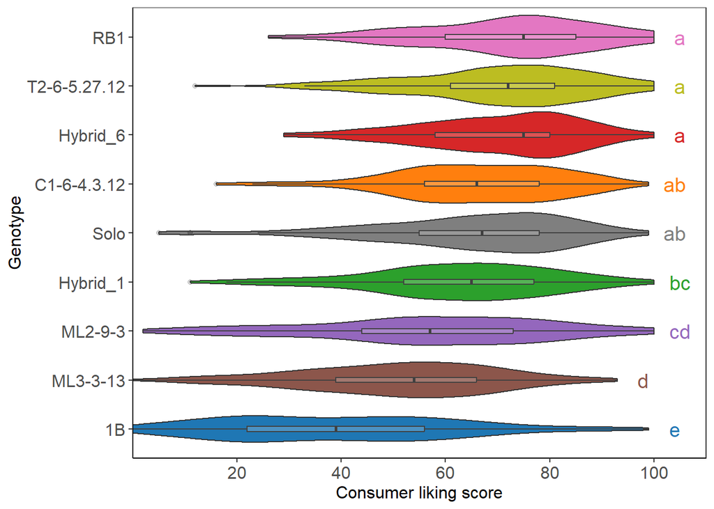

```r
# violin and boxplot plot

ggplot(liking_data, aes(x = reorder(sample,+liking), y = liking)) +
  geom_violin(width=0.95,aes(fill = sample)) +
  geom_boxplot(width=0.1, color="#404040", alpha=0.2) +
  geom_text(data = label_df, aes(x = sample, y = y,
                                 label = groups, color = sample), size = 5) +
  scale_color_manual(values = nine_colours) +
  scale_fill_manual(values = nine_colours) +
  scale_y_continuous(expand = c(0,0), limits = c(0,110),
                     breaks = c(20,40,60,80,100)) +
  coord_flip() + theme_bw()+
  theme(legend.position = "none", panel.grid.major = element_blank(),
        panel.grid.minor = element_blank(), panel.background = element_blank(),
        axis.line = element_line(colour = "black"), axis.text=element_text(size=12),
        axis.title=element_text(size=12)) +
  labs(y="Consumer liking score", x="Genotype")
```

```r
#ggsave("figure/consumer_liking/liking_violin_plot2.pdf", width = 10, height = 8)
```

### Metabolite data visualisation  
This example from [Colantonio et al. (2021)](https://www.pnas.org/doi/full/10.1073/pnas.2115865119) measures the volatiles from 206 tomato accession in a breeding population. This visualisation gives us a distribution of each metabolite class across the population.

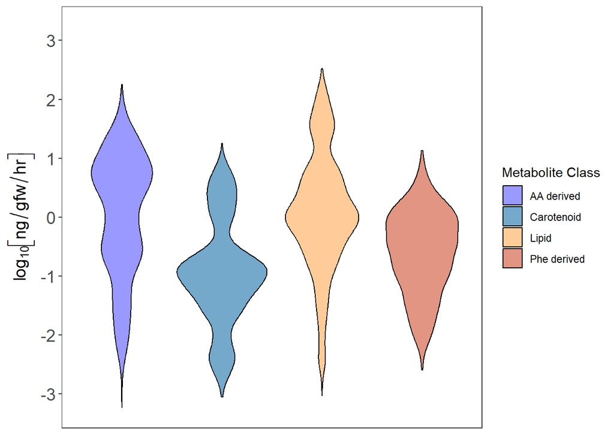

*Distribution of metabolite concentrations for each volatile group across the tomato population. Volatile concentrations are reported in nanograms per gram fresh weight per hour (ng/gfw/h) on a log10scale.*

```r
# Plotting
tmp4 %>%
  ggplot(., aes(x = fig1b_histogram,
                y = log((concentration), 10),
                fill = fig1b_histogram)) +
  geom_violin(color = "black", size = 0.5) +
  ylab(expression(paste(log[10], bgroup("[", ng/gfw/hr, "]")))) +
  scale_y_continuous(limits = c(-3.25, 3.25),
                     breaks = seq(-3, 3, by = 1)) +
  scale_fill_manual(values = c("#9999ffff",
                               "#74a9ccff",
                               "#ffcc99ff",
                               "#e19582ff",
                               "#ccccccff")) +
  labs(fill='Metabolite Class') +
  theme_bw() +
  theme(panel.grid = element_blank(),
        axis.text.x = element_blank(),
        axis.text.y = element_text(size = 14),
        axis.title.x = element_blank(),
        axis.title.y = element_text(size = 14),
        axis.ticks.x = element_blank())
```

Although correlation doesn’t imply causation it can be an important place to start before predictive modeling. Exploring correlations within the dataset can be reported in a table or using corrplot.

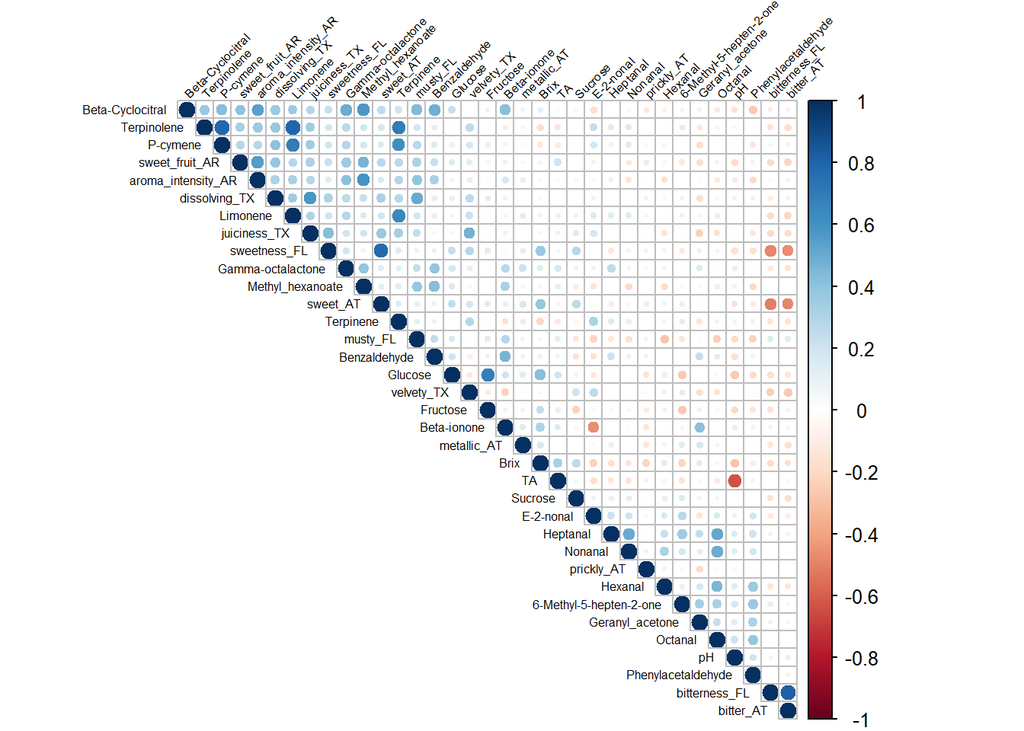

```r
cor_matrix <- read_excel("data/complete_data_matrix.xlsx") %>%
              filter(!assay == "Feb23") %>%
              column_to_rownames("ID") %>%
              select(Hexanal:prickly_AT) %>%
              as.matrix()
# this data contains non-normally distributed data so the non-parametric Kendall method in cor
res <- cor(cor_matrix, method = "kendall")
res1 <- cbind(" "=rownames(round(res, 2)), round(res, 2)) #round values in correlation matrix

#write_xlsx(res1, "results/correlation.xlsx", sheet = "Aug22", overwritesheet = T)

# Visual representation of correlation matrix
corrplot(res, type = "upper", order = "FPC",
         tl.col = "black", tl.srt = 45,tl.cex = 0.5)
```

## Predictive modelling

**Some things to consider**

- There’s no such thing as a perfect model
- Using many features or variables can lead to over-fitting
- Feature engineering can improve the model efficiency and accuracy
- [Feature engineering Blog](https://domino.ai/data-science-dictionary/feature-engineering)
- [Review dealing with complex data and modelling methods](https://link.springer.com/chapter/10.1007/978-981-19-2416-3_1)

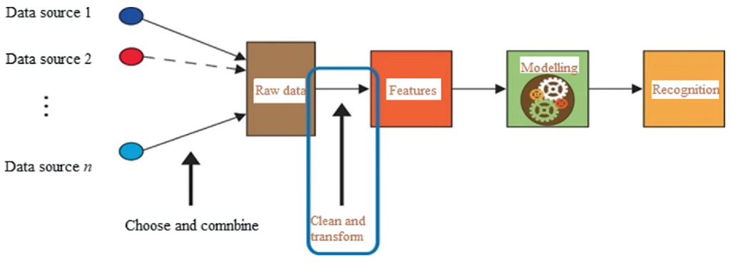

Feature engineering involves transforming raw data into a format that enhances the performance of machine learning models. The key steps in feature engineering include:

- **Data Exploration and Understanding**: Explore and understand the dataset, including the types of features and their distributions. Understanding the shape of the data is key.
- **Handling Missing Data**: Address missing values through imputation or removal of instances or features with missing data. There are many algorithmic approaches to handling missing data.
- **Variable Encoding**: Convert categorical variables into a numerical format suitable for machine learning algorithms using methods.
- **Feature Scaling**: Standardize or normalize numerical features to ensure they are on a similar scale, improving model performance.
- **Feature Creation**: Generate new features by combining existing ones to capture relationships between variables.
- **Handling Outliers**: Identify and address outliers in the data through techniques like trimming or transforming the data.
- **Normalization**: Normalize features to bring them to a common scale, important for algorithms sensitive to feature magnitudes.
- **Binning or Discretization**: Convert continuous features into discrete bins to capture specific patterns in certain ranges.
- **Text Data Processing**: If dealing with text data, perform tasks such as tokenization, stemming, and removing stop words.
- **Time Series Features**: Extract relevant timebased features such as lag features or rolling statistics for time series data.
- **Vector Features**: Vector features are commonly used for training in machine learning. In machine learning, data is represented in the form of features, and these features are often organized into vectors. A vector is a mathematical object that has both magnitude and direction and can be represented as an array of numbers.
- **Feature Selection**: Identify and select the most relevant features to improve model interpretability and efficiency using techniques like univariate feature selection or recursive feature elimination.
- **Feature Extraction**: Feature extraction aims to reduce data complexity (often known as “data dimensionality”) while retaining as much relevant information as possible. This helps to improve the performance and efficiency of machine learning algorithms and simplify the analysis process. Feature extraction may involve the creation of new features (“feature engineering”) and data manipulation to separate and simplify the use of meaningful features from irrelevant ones. Create new features or reduce dimensionality using techniques such as Principal Component Analysis (PCA) or t-Distributed Stochastic Neighbor Embedding (t-DSNE).
- **Cross-validation**: selecting features prior to cross-validation can introduce significant bias. Evaluate the impact of feature engineering on model performance using cross-validation techniques.